# ADA (week 12) Model comparison

# 3 [HOMEWORK]: Comparing (hierarchical) regression models

We are going to revisit an example from week 6 on the mouse-tracking data, where we used categorical variables `group` and `condition` to predict `MAD` measures. We are going to compare different models, including models which only differ with respect to random effects.

Let’s have a look at the data first to remind ourselves:

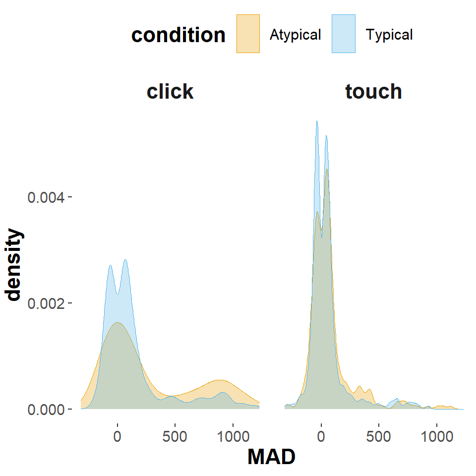

```r
# aggregate
dolphin <- dolphin %>%  filter(correct == 1)

# plotting the data
ggplot(data = dolphin,
       aes(x = MAD,
           color = condition, fill = condition)) +
  geom_density(alpha = 0.3, size = 0, trim = F) +
  facet_grid(~group) +
  xlab("MAD")
```

## 3.a Run some regression models with `brms`

Set up four regression models and run them via `brms`:

1. Store in variable `model1_noInnteraction_FE` a regression with `MAD` as dependent variable, and as explanatory variables `group` and `condition` (but NOT the interaction between these two).
2. Store in variable `model2_interaction_FE` a regression with `MAD` as dependent variable, and as explanatory variables `group`, `condition` and the interaction between these two.
3. Store in variable `model3_interaction_RandSlopes` a model like `model2_interaction_FE` but also adding additionally random effects, namely random intercepts for factor `subject_id`.
4. Store in `model4_interaction_MaxRE` a model like `model2_interaction_FE` but with the maximal random effects structure licensed by the design of the experiment.

**Solution:**

```r
head(dolphin)
```

```
## # A tibble: 6 x 16
##      X1 trial_id   MAD    AUC xpos_flips    RT prototype_label subject_id group
##   <dbl> <chr>    <dbl>  <dbl>      <dbl> <dbl> <chr>                <dbl> <chr>
## 1     1 id0001    82.5 4.02e4          3   950 straight              1001 touch
## 2     2 id0002    44.7 1.39e4          1  1251 straight              1001 touch
## 3     4 id0004   139.  7.41e4          0   690 curved                1001 touch
## 4     5 id0005   402.  2.23e5          2   951 cCoM                  1001 touch
## 5     6 id0006   670.  3.08e5          2  1079 cCoM                  1001 touch
## 6     7 id0007   850.  2.81e5          1  1050 dCoM                  1001 touch
## # ... with 7 more variables: condition <chr>, exemplar <chr>,
## #   category_left <chr>, category_right <chr>, category_correct <chr>,
## #   response <chr>, correct <dbl>
```

```r
model1_noInnteraction_FE <- brm(MAD ~ condition + group, control = list(adapt_delta = 0.95),
               data = dolphin,
               seed = 98)



model2_interaction_FE <- brm(MAD ~ condition*group, control = list(adapt_delta = 0.95),
               data = dolphin,
               seed = 98)


model3_interaction_RandSlopes <- brm(MAD ~ condition*group +
                       (1 | subject_id), control = list(adapt_delta = 0.95),
               data = dolphin,
               seed = 98)


model4_interaction_MaxRE <- brm(MAD ~ condition*group +
                       (condition || subject_id) +
                       (group || exemplar), control = list(adapt_delta = 0.95),
               data = dolphin,
               seed = 98)
```

…